# Problem Set 1 - Geostatistics

Maria Camila Restrepo

2025-01-27

## 1. Running Through an R Demonstration

### Swiss Rainfall Data

The Swiss rainfall data is called the SIC data because it was used in a Spatial Interpolation Comparison (SIC) project back in the late 1990’s.

```r
if (!require(geoR)) install.packages("geoR")
```

[output not shown]

```r
library(geoR)
library(here)
data(SIC)  # this loads the Swiss rainfall dataset from the geoR package into your workspace
#? SIC # A description of the included data objects
names(sic.all)  # component names in the sic.all geodataset
```

```
## $coords
## [1] "V2" "V3"
##
## $data
## [1] "data"
##
## $covariate
## [1] "altitude"
```

```r
# what are the dimensions of the coordinates component?
dim(sic.all$coords)
```

```
## [1] 467   2
```

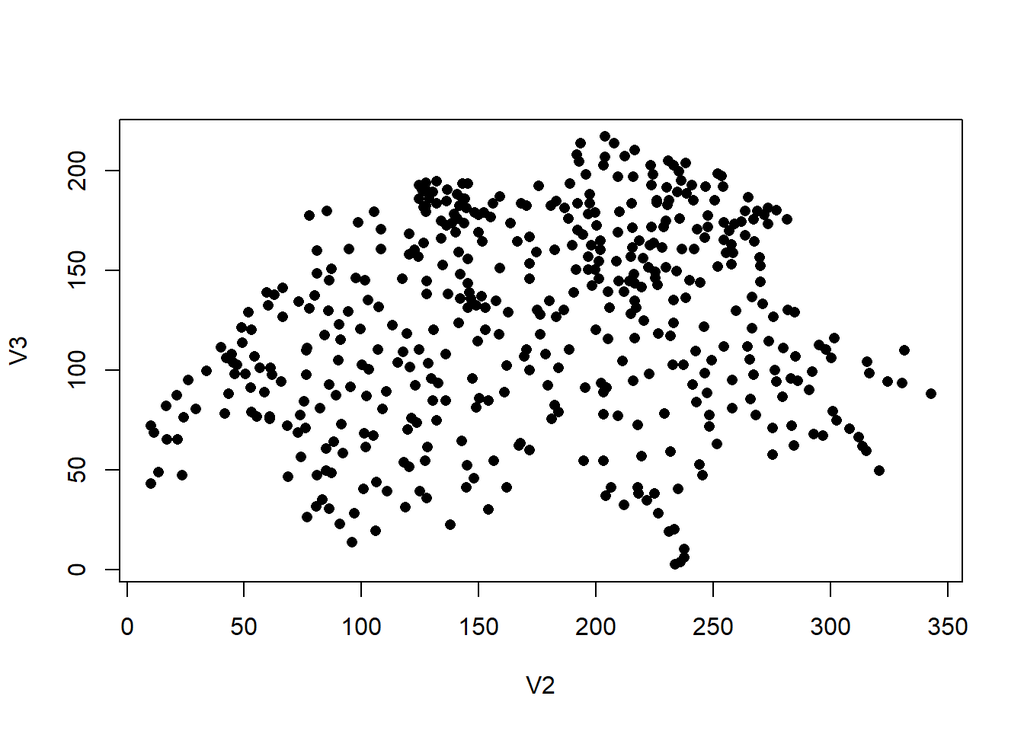

```r
plot(sic.all$coords, pch = 16)
```

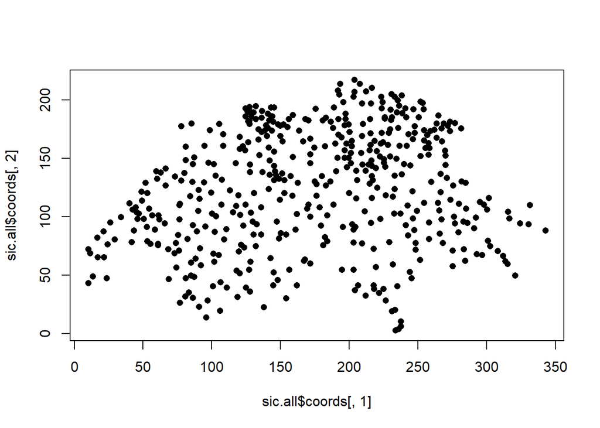

```r
# R by default plots the first column versus the second column when given a matrix. In case you didn't know, this the command below does the same thing, just with different axis labels.  Note I also changed the plotting symbol using pch to be a filled in circle.
plot(sic.all$coords[, 1], sic.all$coords[, 2], pch = 16)
```

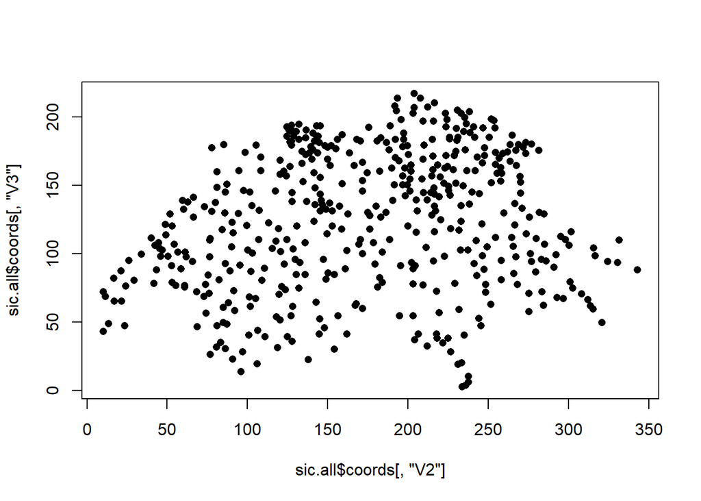

```r
# "[,1]" is shorthand for saying use all the rows and just the column 1. Similarly for "[,2]".
plot(sic.all$coords[, "V2"], sic.all$coords[, "V3"], pch = 16)
```

```r
# "[, "V2"] can also be used to call the "V2" column by name instead of its index number. Similarly
# for "[, "V3"]. Make sure not to forget the comma (the first object in square brackets refers to cells,
# the second object refers to columns).

summary(sic.all$data)
```

```
##    Min. 1st Qu.  Median    Mean 3rd Qu.    Max.
##     0.5    99.5   152.0   184.2   262.5   585.0
```

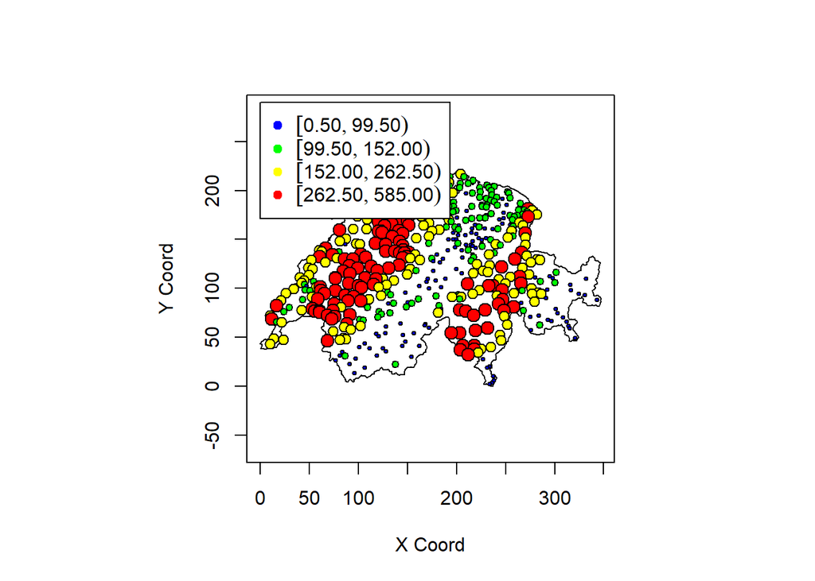

```r
points.geodata(sic.all,
               pt.divide = "quartiles",
               borders = sic.borders,
               x.leg = 0,
               y.leg = 290)
```

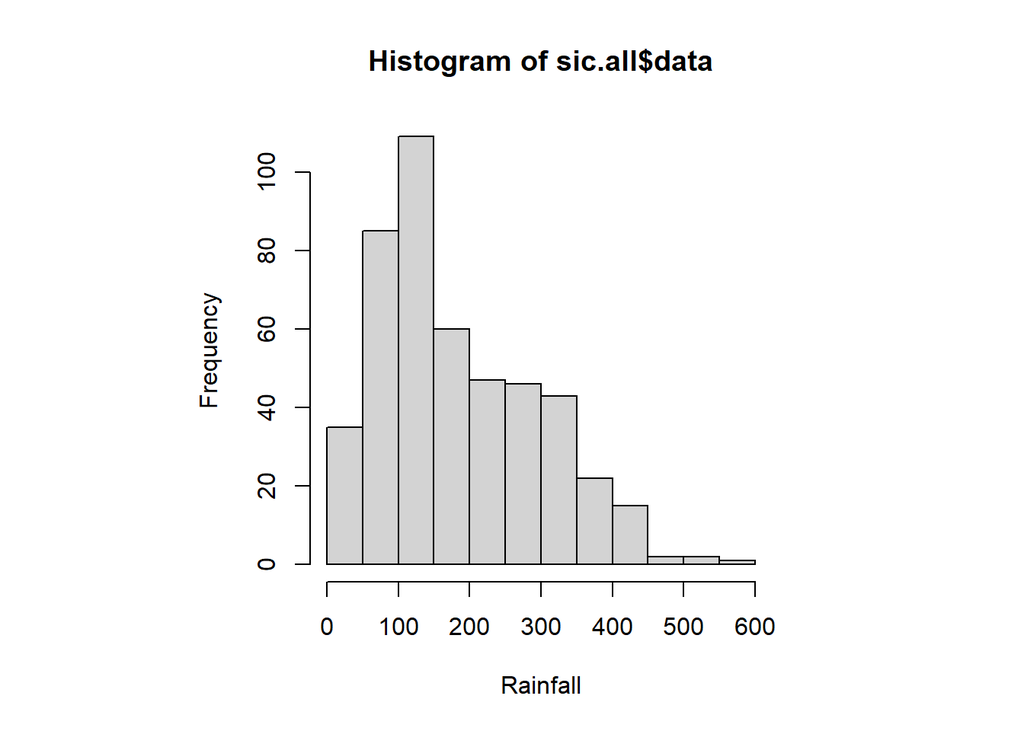

```r
hist(sic.all$data, nclass = 20, xlab = "Rainfall")
```

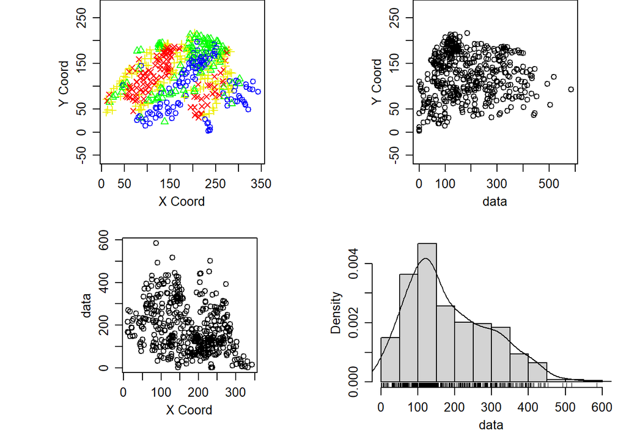

```r
plot(sic.all)  # look at the nice set of plots R produces for this spatial data
```

```r
# The plots in the top left and bottom right are self explanatory, although it would
# be quite helpful to have a legend automatically provided with the top left plot. The
# other two plots, top right and bottom left, are plotting the data versus each coordinate.
# In the top right plot the data is actually on the x-axis and the Y Coordinate of the
# aquifer points on the y-axis.  This is so you can connect to the plot to its immediate
# left since the y-axes are the same.  Similarly for the plot in the bottom left.  The
# x-axis for this one and the plot above it are the same.
```

Questions:

**1. Do you think the rainfall measurements exhibit spatial dependence? Briefly explain and provide a graphic to support your answer.**

Yes, there is spatial dependence in the rainfall measurements. The semivariogram plot shows that the semivariance increases with distance, which is an indication of spatial dependence. The semivariogram plot is shown below.

```r
rain.vario <- variog(sic.all) # enter ?variog in the console to find out more about the object you created
```

```
## variog: computing omnidirectional variogram
```

```r
#?variog
names(rain.vario)
```

```
##  [1] "u"                "v"                "n"                "sd"
##  [5] "bins.lim"         "ind.bin"          "var.mark"         "beta.ols"
##  [9] "output.type"      "max.dist"         "estimator.type"   "n.data"
## [13] "lambda"           "trend"            "pairs.min"        "nugget.tolerance"
## [17] "direction"        "tolerance"        "uvec"             "call"
```

```r
rain.vario$max.dist
```

```
## [1] 335.7076
```

```r
rain.vario <- variog(sic.all, max.dist = 335.7076 / 2) # Restricting to half the actual maximum distance
```

```
## variog: computing omnidirectional variogram
```

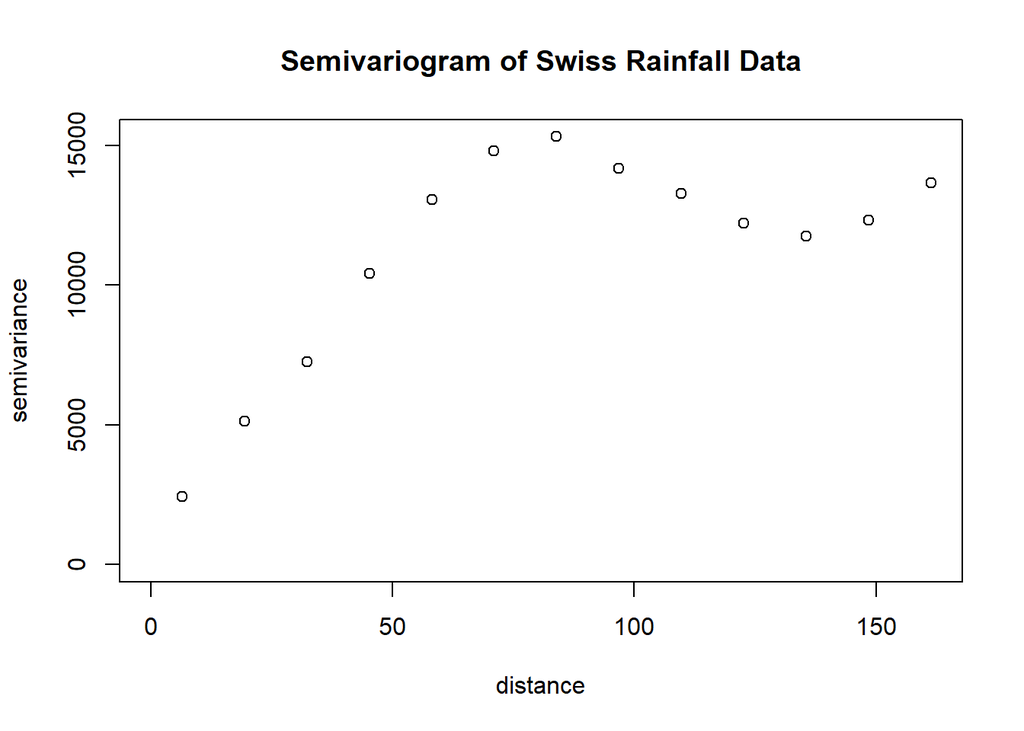

```r
plot(rain.vario)
title("Semivariogram of Swiss Rainfall Data")
```

**b. Do you think the residuals from the linear model regressing the variable altitude (called elevation in class) on rainfall exhibit spatial dependence? Briefly explain and provide a graphic to support your answer.**

```r
rainfall <- sic.all$data
altitude <- sic.all$covariate$altitude

plot(altitude, rainfall, pch = 16)   # Is altitude a good predictor of rainfall?

modelfit2 <- lm(rainfall ~ altitude) # Simple linear regression model with altitude regressed on rainfall

summary(modelfit2)
```

```
##
## Call:
## lm(formula = rainfall ~ altitude)
##
## Residuals:
##     Min      1Q  Median      3Q     Max
## -209.35  -83.84  -24.54   82.39  396.25
##
## Coefficients:
##              Estimate Std. Error t value Pr(>|t|)
## (Intercept) 222.92468   10.76052  20.717  < 2e-16 ***
## altitude     -0.04538    0.01111  -4.084 5.21e-05 ***
## ---
## Signif. codes:  0 '***' 0.001 '**' 0.01 '*' 0.05 '.' 0.1 ' ' 1
##
## Residual standard error: 110.4 on 465 degrees of freedom
## Multiple R-squared:  0.03463,    Adjusted R-squared:  0.03255
## F-statistic: 16.68 on 1 and 465 DF,  p-value: 5.214e-05
```

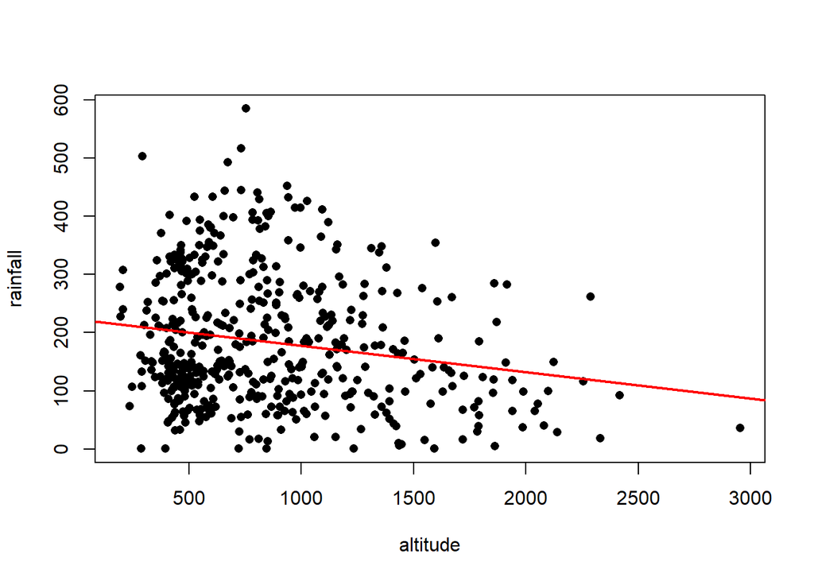

```r
abline(modelfit2$coeff, lwd = 2, col = "red")
```

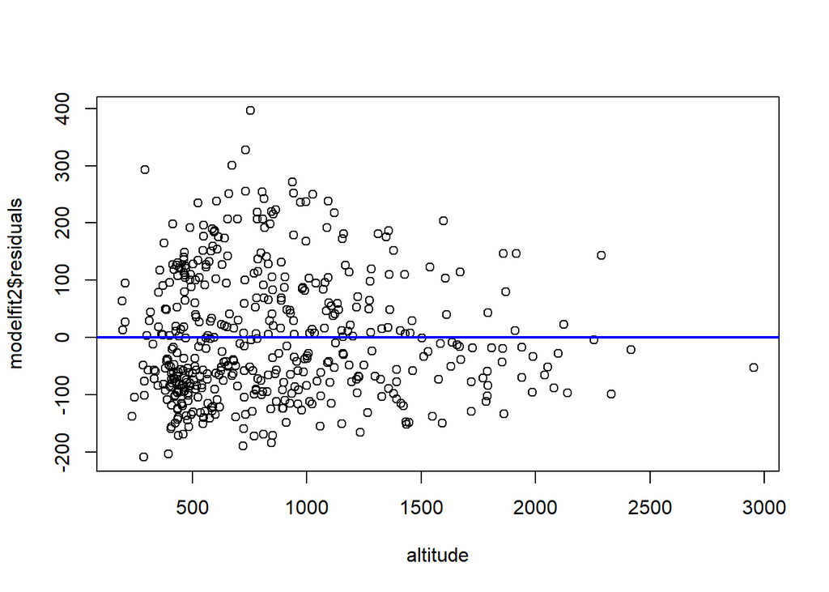

```r
plot(altitude, modelfit2$residuals) # Plot the residuals to check your linear regression assumptions and model fit
abline(h = 0, lwd = 2, col = "blue")
```

**c. Do you think altitude accounted for much of the spatial variation in the rainfall measurements? Briefly explain.**